# ExtraaLearn Project

## Data Preprocessing

- Missing value treatment (if needed)
- Feature engineering (if needed)
- Outlier detection and treatment (if needed)
- Preparing data for modeling
- Any other preprocessing steps (if needed)

**Checking Missing Values**

```python
#Look for any missing values in the data set#
missing_values = data.isnull().sum()
print(missing_values[missing_values > 0])
```

```
Series([], dtype: int64)
```

**Feature engineering**

```python
target_column = 'status'

# Separate the target column
X = data.drop(columns=[target_column])
y = data[target_column]

# Apply one-hot encoding, dropping the first category for each encoded column
X_encoded = pd.get_dummies(X, drop_first=True)

# Concatenate the encoded features with the target column
data_encoded = pd.concat([X_encoded, y], axis=1)

#Convert the Status Column into Converted, Lost#
data_encoded['status'] = data['status'].map({'Converted': 1, 'Lost': 0})
data_encoded.head()
```

|  | age | website_visits | time_spent_on_website | page_views_per_visit | current_occupation_Student | current_occupation_Unemployed | first_interaction_Website | profile_completed_Low | profile_completed_Medium | last_activity_Phone Activity | last_activity_Website Activity | print_media_type1_Yes | print_media_type2_Yes | digital_media_Yes | educational_channels_Yes | referral_Yes | status |
| --- | --- | --- | --- | --- | --- | --- | --- | --- | --- | --- | --- | --- | --- | --- | --- | --- | --- |
| 0 | 57 | 7 | 1639 | 1.861 | False | True | True | False | False | False | True | True | False | True | False | False | 1 |
| 1 | 56 | 2 | 83 | 0.320 | False | False | False | False | True | False | True | False | False | False | True | False | 0 |
| 2 | 52 | 3 | 330 | 0.074 | False | False | True | False | True | False | True | False | False | True | False | False | 0 |
| 3 | 53 | 4 | 464 | 2.057 | False | True | True | False | False | False | True | False | False | False | False | False | 1 |
| 4 | 23 | 4 | 600 | 16.914 | True | False | True | False | False | False | False | False | False | False | False | False | 0 |

```python
#Data Standardization#
scaler = StandardScaler()
df_scaled = scaler.fit_transform(data_encoded)
df_scaled = pd.DataFrame(df_scaled, columns=data_encoded.columns)
df_scaled.head()
```

|  | age | website_visits | time_spent_on_website | page_views_per_visit | current_occupation_Student | current_occupation_Unemployed | first_interaction_Website | profile_completed_Low | profile_completed_Medium | last_activity_Phone Activity | last_activity_Website Activity | print_media_type1_Yes | print_media_type2_Yes | digital_media_Yes | educational_channels_Yes | referral_Yes | status |
| --- | --- | --- | --- | --- | --- | --- | --- | --- | --- | --- | --- | --- | --- | --- | --- | --- | --- |
| 0 | 0.822287 | 1.210912 | 1.227184 | -0.597994 | -0.370126 | 1.483897 | 0.901716 | -0.154355 | -0.972962 | -0.603984 | 1.783255 | 2.875789 | -0.231039 | 2.779363 | -0.425195 | -0.143679 | 1.531013 |
| 1 | 0.746296 | -0.558208 | -0.864765 | -1.382699 | -0.370126 | -0.673901 | -1.108997 | -0.154355 | 1.027789 | -0.603984 | 1.783255 | -0.347731 | -0.231039 | -0.359795 | 2.351861 | -0.143679 | -0.653162 |
| 2 | 0.442330 | -0.204384 | -0.532688 | -1.507966 | -0.370126 | -0.673901 | 0.901716 | -0.154355 | 1.027789 | -0.603984 | 1.783255 | -0.347731 | -0.231039 | 2.779363 | -0.425195 | -0.143679 | -0.653162 |
| 3 | 0.518322 | 0.149440 | -0.352533 | -0.498188 | -0.370126 | 1.483897 | 0.901716 | -0.154355 | -0.972962 | -0.603984 | 1.783255 | -0.347731 | -0.231039 | -0.359795 | -0.425195 | -0.143679 | 1.531013 |
| 4 | -1.761421 | 0.149440 | -0.169690 | 7.067258 | 2.701784 | -0.673901 | 0.901716 | -0.154355 | -0.972962 | -0.603984 | -0.560772 | -0.347731 | -0.231039 | -0.359795 | -0.425195 | -0.143679 | -0.653162 |

```python
#Perform PCA#
pca = PCA(n_components=0.95)  # Retain 95% of the variance
# Fit and transform the scaled data
principal_components = pca.fit_transform(df_scaled)

# Convert the result back into a DataFrame for better readability
df_pca = pd.DataFrame(principal_components)

# Add column names for PCA components
df_pca.columns = [f'PC{i+1}' for i in range(df_pca.shape[1])]

# View the first few rows of the PCA-transformed data
print(df_pca.head())
```

```
        PC1       PC2       PC3       PC4       PC5       PC6       PC7  \
0 -2.304581  1.925871  0.516901 -0.312808  0.298369  1.306276  2.697746
1 -0.142051 -1.133062  2.171373 -0.244957 -0.582144  1.392644 -0.957216
2 -0.449712  0.007264  1.365661 -0.512384 -1.501266  0.513469  1.748808
3 -1.853958  1.349047  1.239546  0.685151 -0.390460 -0.873555 -0.218133
4  3.353022  1.901506 -0.330783 -0.998149  2.910146 -1.625387 -2.238747

        PC8       PC9      PC10      PC11      PC12      PC13      PC14  \
0  1.834389 -1.154192 -1.401746  0.326609  0.063766  2.051615 -0.462235
1  0.277079  1.650106  0.064890  0.657761 -1.459793 -0.511889  0.539159
2  1.569170  0.775190  0.907565  1.757739  0.847951 -0.013426  0.358097
3  0.010756 -0.186276  0.028412  0.109225 -0.165801  1.006094 -1.011796
4  2.092508 -1.264782 -0.138707 -3.155861  3.028501 -1.320649 -1.526627

       PC15
0  0.691311
1  0.957103
2  1.037151
3  0.791963
4 -1.486884
```

```
[0.11169253 0.09333729 0.07712673 0.06890895 0.0668351  0.06127863
 0.05997487 0.05829467 0.05807018 0.05735751 0.05428017 0.05349885
 0.0512634  0.04764686 0.03858933]
```

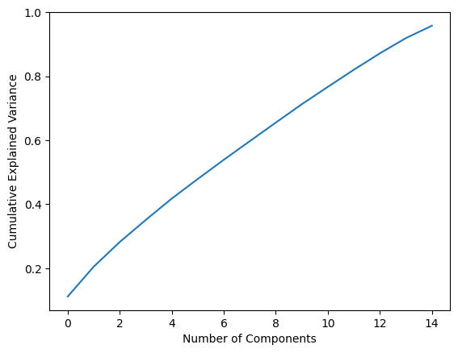

```python
# Get explained variance for each principal component
explained_variance = pca.explained_variance_ratio_
print(explained_variance)

# Plot cumulative explained variance
plt.plot(np.cumsum(explained_variance))
plt.xlabel('Number of Components')
plt.ylabel('Cumulative Explained Variance')
plt.show()
```

**PCA Analysis:** none of the components explain a particularly large portion of the variance on their own. The highest value is 0.1117, meaning the first component explains only about 11.17% of the variance, which is relatively low.

Each component contributes some degree of variance.

**Outliers Detection**

```python
#We will perform DBSCAN Clustering#
#Analyze to chose the correct epsilon#
#min samples = data size +1#



# Set k
min_samples = 16
k = min_samples + 1  # This is a common choice

# Fit Nearest Neighbors model
nbrs = NearestNeighbors(n_neighbors=k).fit(df_scaled)

# Get distances to the k-th nearest neighbor
distances, indices = nbrs.kneighbors(df_scaled)

# Sort the distances
distances = np.sort(distances[:, k-1], axis=0)
```

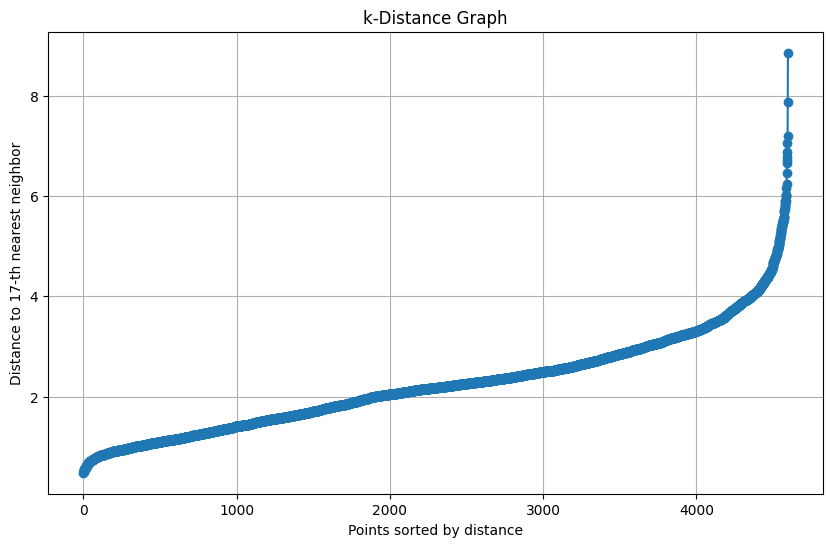

```python
#Plot K-Distance#
plt.figure(figsize=(10, 6))
plt.plot(distances, marker='o')
plt.title('k-Distance Graph')
plt.xlabel('Points sorted by distance')
plt.ylabel('Distance to {}-th nearest neighbor'.format(k))
plt.grid()
plt.show()
```

epsilon would be 4.5

```python
dbscan = DBSCAN(eps=4.5, min_samples=16)  # Adjust parameters as needed
dbscan.fit(df_scaled)
clusters = dbscan.fit_predict(df_scaled)
```

```python
# Count the number of points in each cluster
unique, counts = np.unique(clusters, return_counts=True)
cluster_counts = dict(zip(unique, counts))
print("Cluster counts:", cluster_counts)

# Extract outliers
outliers = df_scaled[clusters == -1]
print(f"Number of outliers detected: {len(outliers)}")
```

```
Cluster counts: {-1: 37, 0: 4174, 1: 216, 2: 75, 3: 96}
Number of outliers detected: 37
```

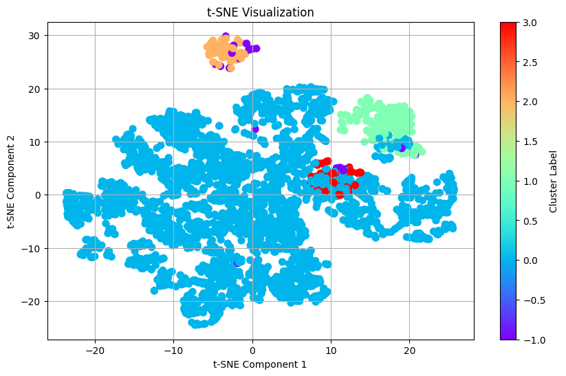

```python
# Scaled high-dimensional data
tsne = TSNE(n_components=3, random_state=42)
tsne_result = tsne.fit_transform(df_scaled)

# Visualize the result
plt.figure(figsize=(10, 6))
plt.scatter(tsne_result[:, 0], tsne_result[:, 1], c=clusters, cmap='rainbow', s=50)
plt.title('t-SNE Visualization')
plt.xlabel('t-SNE Component 1')
plt.ylabel('t-SNE Component 2')
plt.colorbar(label='Cluster Label')
plt.grid()
plt.show()
```

```python
df1 = data_encoded.copy()
df1 = pd.get_dummies(df1, columns=['status'], drop_first=True)
df1['Cluster'] = clusters
df1.head()
```

|  | age | website_visits | time_spent_on_website | page_views_per_visit | current_occupation_Student | current_occupation_Unemployed | first_interaction_Website | profile_completed_Low | profile_completed_Medium | last_activity_Phone Activity | last_activity_Website Activity | print_media_type1_Yes | print_media_type2_Yes | digital_media_Yes | educational_channels_Yes | referral_Yes | status_1 | Cluster |
| --- | --- | --- | --- | --- | --- | --- | --- | --- | --- | --- | --- | --- | --- | --- | --- | --- | --- | --- |
| 0 | 57 | 7 | 1639 | 1.861 | False | True | True | False | False | False | True | True | False | True | False | False | True | 0 |
| 1 | 56 | 2 | 83 | 0.320 | False | False | False | False | True | False | True | False | False | False | True | False | False | 0 |
| 2 | 52 | 3 | 330 | 0.074 | False | False | True | False | True | False | True | False | False | True | False | False | False | 0 |
| 3 | 53 | 4 | 464 | 2.057 | False | True | True | False | False | False | True | False | False | False | False | False | True | 0 |
| 4 | 23 | 4 | 600 | 16.914 | True | False | True | False | False | False | False | False | False | False | False | False | False | 0 |

```python
#Cluster Profiling# #Numerical#
numerical_vars = df1.select_dtypes(include=['int64']).columns.tolist()
cluster_groups = df1.groupby('Cluster')
numerical_summary = cluster_groups[numerical_vars].agg(['count','mean','std'])
print("Numerical Summary:")
print(numerical_summary)
```

```
Numerical Summary:
          age                       website_visits                      \
        count       mean        std          count      mean       std
Cluster
-1         37  38.054054  14.946099             37  7.351351  9.280254
 0       4174  46.196933  13.173510           4174  3.529468  2.700298
 1        216  47.319444  12.471541            216  3.708333  2.627781
 2         75  47.920000  12.743583             75  3.760000  2.705550
 3         96  44.614583  12.714161             96  3.781250  2.567830

        time_spent_on_website                          Cluster
                        count         mean         std   count mean  std
Cluster
-1                         37   718.270270  695.586389      37 -1.0  0.0
 0                       4174   725.658361  744.670702    4174  0.0  0.0
 1                        216   782.388889  755.266105     216  1.0  0.0
 2                         75  1122.760000  802.127675      75  2.0  0.0
 3                         96   317.322917  377.586142      96  3.0  0.0
```

```python
#Checking results for the categorical variables#
categorical_vars = df1.select_dtypes(include=['bool']).columns.tolist()
cluster_groups = df1.groupby('Cluster')[categorical_vars].sum()
cluster_groups.style.highlight_max(color = "lightgreen", axis = 0)
```

| Cluster | current_occupation_Student | current_occupation_Unemployed | first_interaction_Website | profile_completed_Low | profile_completed_Medium | last_activity_Phone Activity | last_activity_Website Activity | print_media_type1_Yes | print_media_type2_Yes | digital_media_Yes | educational_channels_Yes | referral_Yes | status_1 |
| --- | --- | --- | --- | --- | --- | --- | --- | --- | --- | --- | --- | --- | --- |
| -1 | 14 | 2 | 15 | 11 | 12 | 5 | 12 | 12 | 17 | 11 | 16 | 18 | 12 |
| 0 | 503 | 1317 | 2295 | 0 | 2087 | 1117 | 994 | 444 | 0 | 482 | 626 | 0 | 1233 |
| 1 | 20 | 64 | 116 | 0 | 109 | 64 | 49 | 26 | 216 | 24 | 36 | 0 | 70 |
| 2 | 7 | 21 | 53 | 0 | 28 | 17 | 16 | 5 | 0 | 4 | 9 | 75 | 52 |
| 3 | 10 | 32 | 57 | 96 | 0 | 26 | 29 | 9 | 0 | 6 | 17 | 0 | 8 |

In this case we are going to keep the outliers, since can be treated as a seprate group

**Data Preprocessing**

```python
# Separating the target variable and other variables
Y = df1.status_1

X = df1.drop(['status_1', 'Cluster'], axis=1)
X_train, X_test, y_train, y_test = train_test_split(X, Y, test_size=0.3, random_state=1)
```

## Build a decision tree

```python
# Building decision tree model
dt = DecisionTreeClassifier( random_state = 42)
dt
```

```
DecisionTreeClassifier(random_state=42)
```

```python
# Fitting decision tree model
dt.fit(X_train, y_train)
```

```
DecisionTreeClassifier(random_state=42)
```

## Model Performance evaluation and improvement

```python
def metrics_score(actual, predicted):

    print(classification_report(actual, predicted))

    cm = confusion_matrix(actual, predicted)

    plt.figure(figsize = (8, 5))

    sns.heatmap(cm, annot = True, fmt = '.2f', xticklabels = ['Converted', 'Lost'], yticklabels = ['Converted', 'Lost'])
    plt.ylabel('Actual')

    plt.xlabel('Predicted')

    plt.show()
```

```python
def model_performance_classification(model, predictors, target):
    """
    Function to compute different metrics to check classification model performance

    model: classifier

    predictors: independent variables

    target: dependent variable
    """

    # Predicting using the independent variables
    pred = model.predict(predictors)

    recall = recall_score(target, pred,average = 'macro')                 # To compute recall

    precision = precision_score(target, pred, average = 'macro')              # To compute precision

    acc = accuracy_score(target, pred)                                 # To compute accuracy score


    # Creating a dataframe of metrics

    df_perf = pd.DataFrame(
        {
            "Precision":  precision,
            "Recall":  recall,
            "Accuracy": acc,
        },

        index = [0],
    )

    return df_perf
```

```
              precision    recall  f1-score   support

       False       1.00      1.00      1.00      2243
        True       1.00      1.00      1.00       975

    accuracy                           1.00      3218
   macro avg       1.00      1.00      1.00      3218
weighted avg       1.00      1.00      1.00      3218
```

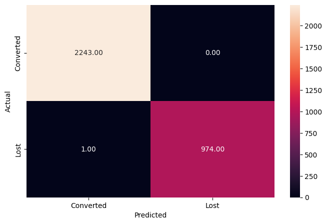

```python
# Checking performance on the training dataset
y_train_pred_dt = dt.predict(X_train)

metrics_score(y_train, y_train_pred_dt)
```

Observation:

The Decision tree is giving a 100% score for all metrics on the training dataset.

```
              precision    recall  f1-score   support

       False       0.85      0.85      0.85       980
        True       0.63      0.63      0.63       400

    accuracy                           0.79      1380
   macro avg       0.74      0.74      0.74      1380
weighted avg       0.79      0.79      0.79      1380
```

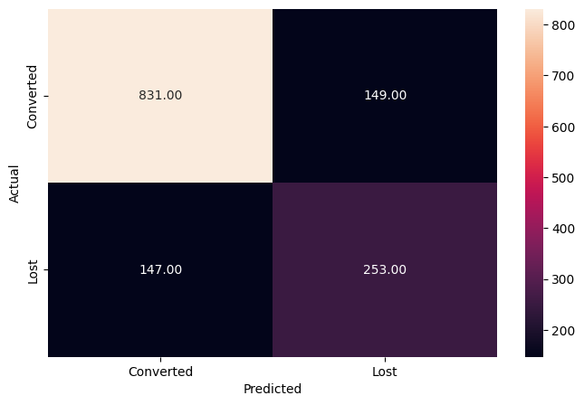

```python
# Checking performance on the test dataset
y_test_pred_dt = dt.predict(X_test)

metrics_score(y_test, y_test_pred_dt)
```

```python
dtree_test = model_performance_classification(dt,X_test,y_test)
dtree_test
```

|  | Precision | Recall | Accuracy |
| --- | --- | --- | --- |
| 0 | 0.739523 | 0.74023 | 0.785507 |

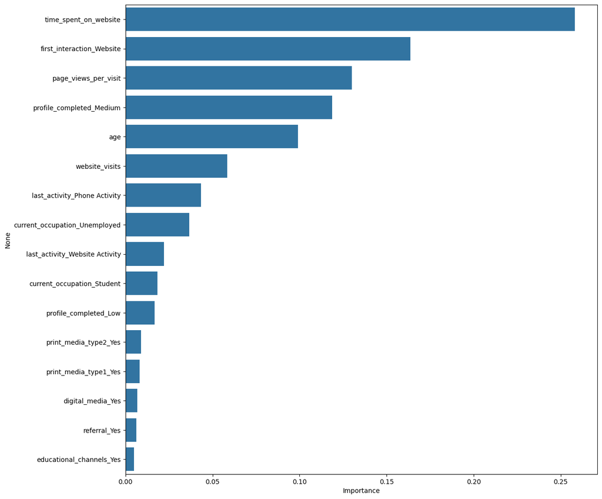

```python
# Plot the feature importance

importances = dt.feature_importances_

columns = X.columns

importance_df = pd.DataFrame(importances, index = columns, columns = ['Importance']).sort_values(by = 'Importance', ascending = False)

plt.figure(figsize = (13, 13))

sns.barplot(x=importance_df.Importance,y=importance_df.index);
```

**Tunning the model**

```python
# Choose the type of classifier
dtree_estimator = DecisionTreeClassifier(random_state = 1)

# Grid of parameters to choose from
parameters = {'max_depth': np.arange(2, 7),
              'criterion': ['gini', 'entropy'],
              'min_samples_leaf': [5, 10, 20, 25]
             }

# Type of scoring used to compare parameter combinations
scorer = metrics.make_scorer(recall_score, pos_label = 1)

# Run the grid search
gridCV = GridSearchCV(dtree_estimator, parameters, scoring = scorer, cv = 10)

# Fitting the grid search on the train data
gridCV = gridCV.fit(X_train, y_train)

# Set the classifier to the best combination of parameters
dtree_estimator = gridCV.best_estimator_

# Fit the best estimator to the data
dtree_estimator.fit(X_train, y_train)
```

```
DecisionTreeClassifier(max_depth=4, min_samples_leaf=5, random_state=1)
```

```
              precision    recall  f1-score   support

       False       0.92      0.85      0.89      2243
        True       0.71      0.84      0.77       975

    accuracy                           0.85      3218
   macro avg       0.82      0.85      0.83      3218
weighted avg       0.86      0.85      0.85      3218
```

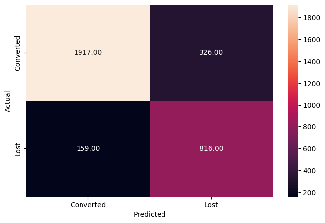

```python
# Checking performance on the training dataset
y_train_pred_dt = dtree_estimator.predict(X_train)

metrics_score(y_train, y_train_pred_dt)
```

**Observation:**

- In comparison to the model with default values of hyperparameters, **the performance on the training set has gone down significantly.** This makes sense because we are trying to reduce overfitting.

```
              precision    recall  f1-score   support

       False       0.91      0.84      0.87       980
        True       0.67      0.79      0.72       400

    accuracy                           0.82      1380
   macro avg       0.79      0.82      0.80      1380
weighted avg       0.84      0.82      0.83      1380
```

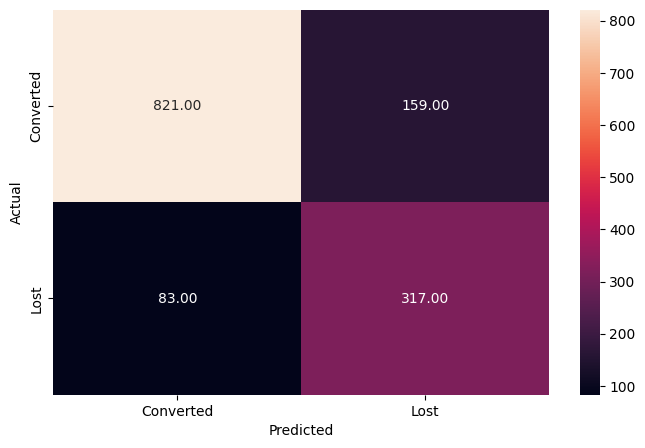

```python
# Checking performance on the test dataset
y_test_pred_dt = dtree_estimator.predict(X_test)

metrics_score(y_test, y_test_pred_dt)
```

```python
dtree_tuned_test = model_performance_classification(dtree_estimator,X_test,y_test)
dtree_tuned_test
```

|  | Precision | Recall | Accuracy |
| --- | --- | --- | --- |
| 0 | 0.787076 | 0.815128 | 0.824638 |

Observations:

## Building a Random Forest model

```python
# Fitting the Random Forest classifier on the training data
rf_estimator = RandomForestClassifier( random_state = 1)

rf_estimator.fit(X_train, y_train)
```

```
RandomForestClassifier(random_state=1)
```

```
              precision    recall  f1-score   support

       False       1.00      1.00      1.00      2243
        True       1.00      1.00      1.00       975

    accuracy                           1.00      3218
   macro avg       1.00      1.00      1.00      3218
weighted avg       1.00      1.00      1.00      3218
```

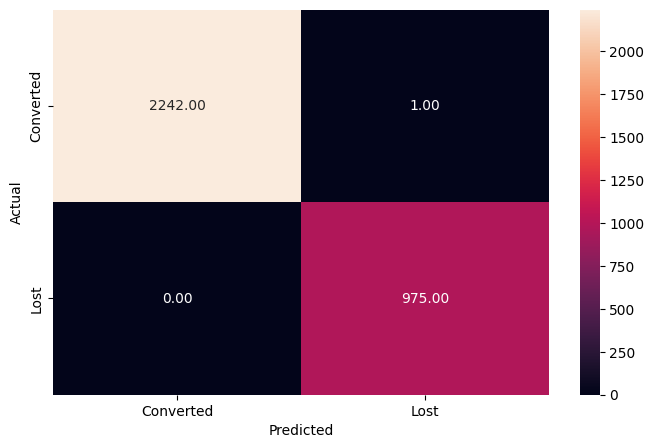

```python
# Checking performance on the training data
y_pred_train_rf = rf_estimator.predict(X_train)

metrics_score(y_train, y_pred_train_rf)
```

Observation:

The Random Forest is giving a 100% score for all metrics on the training dataset.

## Model Performance evaluation and improvement

```python
rf_estimator_test = model_performance_classification(rf_estimator,X_test,y_test)
rf_estimator_test
```

|  | Precision | Recall | Accuracy |
| --- | --- | --- | --- |
| 0 | 0.818097 | 0.800102 | 0.846377 |

Precision (0.818): About 82% of the positive predictions made by the model are correct, meaning it has a good ability to avoid false positives.

Recall (0.800): The model correctly identifies 80% of the actual positive cases, suggesting that it performs well in minimizing false negatives.

Accuracy (0.846): The model correctly classifies 84.6% of the total data points, showing strong overall performance.

Conclusion: The model demonstrates a strong balance between precision, recall, and accuracy, indicating that it is well-calibrated for minimizing both false positives and false negatives while maintaining high overall correctness.

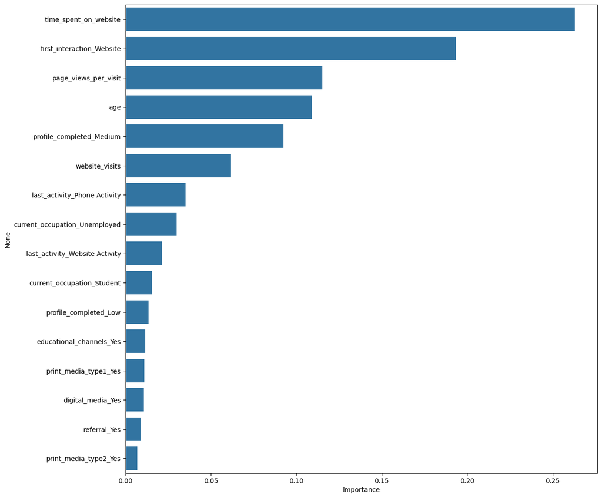

```python
# Plotting feature importance
importances = rf_estimator.feature_importances_

columns = X.columns

importance_df = pd.DataFrame(importances, index = columns, columns = ['Importance']).sort_values(by = 'Importance', ascending = False)

plt.figure(figsize = (13, 13))

sns.barplot(x= importance_df.Importance, y=importance_df.index);
```

**Tunning the model**

```python
# Choose the type of classifier
rf_estimator_tuned = RandomForestClassifier( random_state = 1)

# Grid of parameters to choose from
params_rf = {
        "n_estimators": [100, 250, 500],
        "min_samples_leaf": np.arange(1, 4, 1),
        "max_features": [0.7, 0.9, 'auto'],
}


# Type of scoring used to compare parameter combinations - recall score for class 1
scorer = metrics.make_scorer(recall_score, pos_label = 1)

# Run the grid search
grid_obj = GridSearchCV(rf_estimator_tuned, params_rf, scoring = scorer, cv = 5)

grid_obj = grid_obj.fit(X_train, y_train)

# Set the classifier to the best combination of parameters
rf_estimator_tuned = grid_obj.best_estimator_
```

```python
rf_estimator_tuned.fit(X_train, y_train)
```

```
RandomForestClassifier(max_features=0.9, min_samples_leaf=3, n_estimators=500,
                       random_state=1)
```

```
              precision    recall  f1-score   support

       False       0.96      0.97      0.97      2243
        True       0.94      0.91      0.92       975

    accuracy                           0.95      3218
   macro avg       0.95      0.94      0.94      3218
weighted avg       0.95      0.95      0.95      3218
```

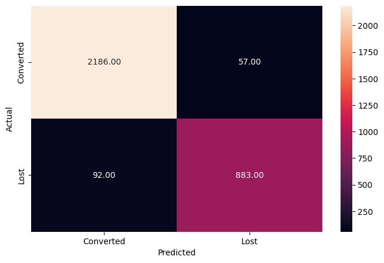

```python
# Checking performance on the training data
y_pred_train_rf_tuned = rf_estimator_tuned.predict(X_train)

metrics_score(y_train, y_pred_train_rf_tuned)
```

```
              precision    recall  f1-score   support

       False       0.89      0.90      0.89       980
        True       0.75      0.71      0.73       400

    accuracy                           0.85      1380
   macro avg       0.82      0.81      0.81      1380
weighted avg       0.85      0.85      0.85      1380
```

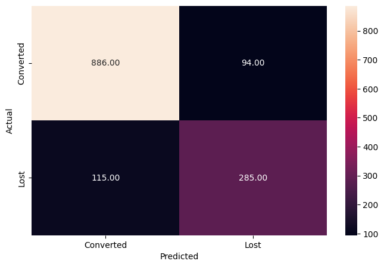

```python
#Checking performance on the test data
y_pred_test_rf_tuned = rf_estimator_tuned.predict(X_test)

metrics_score(y_test, y_pred_test_rf_tuned)
```

```python
rf_estimator_tuned_test = model_performance_classification(rf_estimator_tuned, X_test, y_test)
rf_estimator_tuned_test
```

|  | Precision | Recall | Accuracy |
| --- | --- | --- | --- |
| 0 | 0.818547 | 0.808291 | 0.848551 |

The random forest model confirm the insights that we got from the decision tree. The random forest uses more computational resources and does not imrpove the model accuracy a lot. Only 2% even after the tunin process. Using a decision tree should suffice in this case.

## Actionable Insights and Recommendations

Key Insights:

Actionable Recommendation: To improve conversion rates, it would be beneficial to implement strategies aimed at enhancing user engagement on the website. This may include:

- Optimizing content to encourage exploration
- Enhancing navigation to facilitate easy access to information.
- Implementing features like personalized recommendations to keep users engaged.

**Profile of Leads Likely to Convert**

- Based on the analysis and insights derived from machine learning algorithms, including clustering, we recommend focusing on leads with the following characteristics

**Demographic Factors:**

- Employment Status: Leads identified as unemployed or professionals are more likely to convert.
- Age: Leads over the age of 40 show a higher propensity to convert, suggesting that this demographic may be more engaged and responsive.

**Engagement Metrics:**

**Actionable Insights**:

- Targeted Marketing: Create marketing strategies specifically aimed at engaging unemployed individuals and professionals over the age of 40.
- Referral Programs: Since referral leads show higher conversion rates, consider implementing or enhancing referral programs to encourage more referrals, even if they currently constitute a small portion of total leads.
- Website Engagement Strategies: Develop features and content that cater to the interests of these demographics to maximize engagement and conversion potential. By concentrating efforts on these identified lead profiles, the chances of successfully converting leads into paying customers can be significantly enhanced.